# AN588-Week-10

Brooke Rothamer

2023-11-09

# Module 16: Model Selection in General Linear Regression

The purpose of a model selection process in a regression analysis is to sort through our explanatory variables in a systematic fashion in order to establish which are best able to describe the response. There are different possible algorithms to use for model selection, e.g., forward and backward selection, which may result in different parameters being included in the final model.

#### Nested Comparisons

One way we can compare different models is to use F ratios and what are called partial F tests. This approach looks at two or more nested models: a larger model that contains explanatory variables that we are interested in and smaller, less complex models that exclude one or more of those variables. Basically, we aim to compare the variance in the response variable explained by the more complex model to that explained by a “reduced” model. If the more complex model explains a significantly greater proportion of the variation, then we conclude that predictor terms absent from the less complex model are important.

For example, if including an additional term with its associated β coefficient results in significantly better fit to the observed data than we find for a model that lacks that particular terms, then this is evidence against the null hypothesis that the β coefficient (slope) for that term equals zero.

#### Example:

Let’s go back to our zombie data and compare a few models. We need to calculate the following partial F statistic for the full versus reduced model.

F = (R^2full - R^2reduced)(n-q-1) / (1-R^2full)(q-p)

where:

The R2 values are the coefficients of determination of the full model and the nested “reduced”” model

n is the number of observations in the data set

p is the number of predictor terms in the nested (reduced) model

q is the number of predictor terms in the full model

After we calculate this F statistic, we compare it to an F distribution with df1 = q-p and df2 = n-q to derive a p value. The lm() function will do this for us automatically, but we can also do it by hand.

```r
library(curl)
f <- curl("https://raw.githubusercontent.com/fuzzyatelin/fuzzyatelin.github.io/master/AN588_Fall21/zombies.csv")
z <- read.csv(f, header = TRUE, sep = ",", stringsAsFactors = TRUE)
m1 <- lm(data = z, height ~ age * gender)  # full model
m2 <- lm(data = z, height ~ age + gender)  # model without interactions
m3 <- lm(data = z, height ~ age)  # model with one predictor
m4 <- lm(data = z, height ~ 1)  # intercept only model
```

Once we have fitted these nested models, we can carry out partial F tests to compare particular models using the anova() function, with the nested (reduced) and full model as arguments. The reduced model is included as the 1st argument and the full model is included as the second argument.

```r
anova(m2, m1, test = "F")  # compares the reduced model without interactions (m2) to the full model with interactions (m1)
```

```
## Analysis of Variance Table
##
## Model 1: height ~ age + gender
## Model 2: height ~ age * gender
##   Res.Df    RSS Df Sum of Sq     F  Pr(>F)
## 1    997 6752.7
## 2    996 6708.6  1    44.138 6.553 0.01062 *
## ---
## Signif. codes:  0 '***' 0.001 '**' 0.01 '*' 0.05 '.' 0.1 ' ' 1
```

We can also calculate the F statistic by hand and compare it to the F distribution.

```r
f <- ((summary(m1)$r.squared - summary(m2)$r.squared) * (nrow(z) - 3 - 1))/((1 -
    summary(m1)$r.squared) * (3 - 2))
f
```

```
## [1] 6.552973
```

```r
p <- 1 - pf(f, df1 = 3 - 2, df2 = nrow(z) - 3, lower.tail = TRUE)  # df1 = q-p, df2 = n-q
p
```

```
## [1] 0.01061738
```

```r
anova(m3, m2, test = "F")  # compares the age only model (m3) to the age + gender model (m2)
```

```
## Analysis of Variance Table
##
## Model 1: height ~ age
## Model 2: height ~ age + gender
##   Res.Df     RSS Df Sum of Sq      F    Pr(>F)
## 1    998 10756.6
## 2    997  6752.7  1    4003.9 591.15 < 2.2e-16 ***
## ---
## Signif. codes:  0 '***' 0.001 '**' 0.01 '*' 0.05 '.' 0.1 ' ' 1
```

```r
f <- ((summary(m2)$r.squared - summary(m3)$r.squared) * (nrow(z) - 2 - 1))/((1 -
    summary(m2)$r.squared) * (2 - 1))
f
```

```
## [1] 591.147
```

```r
p <- 1 - pf(f, df1 = 2 - 1, df2 = nrow(z) - 2, lower.tail = TRUE)  # df1 = q-p, df2 = n-q
p
```

```
## [1] 0
```

In these cases, each comparison shows that the more complex model indeed results in signficantly more explantory power than the reduced model.

#### Forward Selection

Forward selection starts with an intercept-only model and then tests which of the predictor variables best improves the goodness-of-fit. Then the model is updated by adding that term and tests which of the remaining predictors would further and best improve the fit. The process continues until there are not any other terms that could be added to improve the fit more. The R functions add1() and update(), respectively, perform the series of tests and update your fitted regression model. Setting the test= argument to “F” includes the partial F statistic value and its significance. The “.~.” part of the scope= argument means, basically, “what is already there”, while the remainder of the scope argument is the list of additional variables you might add for the fullest possible model.

```r
m0 <- lm(data = z, height ~ 1)
summary(m0)
```

```
##
## Call:
## lm(formula = height ~ 1, data = z)
##
## Residuals:
##      Min       1Q   Median       3Q      Max
## -13.4806  -2.9511  -0.1279   2.7530  12.8997
##
## Coefficients:
##             Estimate Std. Error t value Pr(>|t|)
## (Intercept)  67.6301     0.1363   496.2   <2e-16 ***
## ---
## Signif. codes:  0 '***' 0.001 '**' 0.01 '*' 0.05 '.' 0.1 ' ' 1
##
## Residual standard error: 4.31 on 999 degrees of freedom
```

```r
add1(m0, scope = . ~ . + age + weight + zombies_killed + years_of_education,
    test = "F")
```

```
## Single term additions
##
## Model:
## height ~ 1
##                    Df Sum of Sq     RSS    AIC   F value  Pr(>F)
## <none>                          18558.6 2922.9
## age                 1    7802.0 10756.6 2379.5  723.8676 < 2e-16 ***
## weight              1   12864.8  5693.8 1743.4 2254.9310 < 2e-16 ***
## zombies_killed      1       5.7 18552.9 2924.6    0.3048 0.58100
## years_of_education  1      81.6 18477.0 2920.5    4.4057 0.03607 *
## ---
## Signif. codes:  0 '***' 0.001 '**' 0.01 '*' 0.05 '.' 0.1 ' ' 1
```

```r
m1 <- update(m0, formula = . ~ . + weight)
summary(m1)
```

```
##
## Call:
## lm(formula = height ~ weight, data = z)
##
## Residuals:
##     Min      1Q  Median      3Q     Max
## -7.1519 -1.5206 -0.0535  1.5167  9.4439
##
## Coefficients:
##              Estimate Std. Error t value Pr(>|t|)
## (Intercept) 39.565446   0.595815   66.41   <2e-16 ***
## weight       0.195019   0.004107   47.49   <2e-16 ***
## ---
## Signif. codes:  0 '***' 0.001 '**' 0.01 '*' 0.05 '.' 0.1 ' ' 1
##
## Residual standard error: 2.389 on 998 degrees of freedom
## Multiple R-squared:  0.6932, Adjusted R-squared:  0.6929
## F-statistic:  2255 on 1 and 998 DF,  p-value: < 2.2e-16
```

```r
add1(m1, scope = . ~ . + age + weight + zombies_killed + years_of_education,
    test = "F")
```

```
## Single term additions
##
## Model:
## height ~ weight
##                    Df Sum of Sq    RSS     AIC   F value  Pr(>F)
## <none>                          5693.8 1743.38
## age                 1   3012.83 2681.0  992.17 1120.4147 < 2e-16 ***
## zombies_killed      1      5.16 5688.6 1744.47    0.9052 0.34163
## years_of_education  1     16.93 5676.9 1742.40    2.9728 0.08498 .
## ---
## Signif. codes:  0 '***' 0.001 '**' 0.01 '*' 0.05 '.' 0.1 ' ' 1
```

```r
m2 <- update(m1, formula = . ~ . + age)
summary(m2)
```

```
##
## Call:
## lm(formula = height ~ weight + age, data = z)
##
## Residuals:
##     Min      1Q  Median      3Q     Max
## -5.2278 -1.1782 -0.0574  1.1566  5.4117
##
## Coefficients:
##              Estimate Std. Error t value Pr(>|t|)
## (Intercept) 31.763388   0.470797   67.47   <2e-16 ***
## weight       0.163107   0.002976   54.80   <2e-16 ***
## age          0.618270   0.018471   33.47   <2e-16 ***
## ---
## Signif. codes:  0 '***' 0.001 '**' 0.01 '*' 0.05 '.' 0.1 ' ' 1
##
## Residual standard error: 1.64 on 997 degrees of freedom
## Multiple R-squared:  0.8555, Adjusted R-squared:  0.8553
## F-statistic:  2952 on 2 and 997 DF,  p-value: < 2.2e-16
```

```r
add1(m2, scope = . ~ . + age + weight + zombies_killed + years_of_education,
    test = "F")
```

```
## Single term additions
##
## Model:
## height ~ weight + age
##                    Df Sum of Sq    RSS    AIC F value Pr(>F)
## <none>                          2681.0 992.17
## zombies_killed      1   2.62551 2678.3 993.20  0.9764 0.3233
## years_of_education  1   0.77683 2680.2 993.89  0.2887 0.5912
```

After we add weight and age, no other variable improves the fit of the model significantly, so the final, best model in this case is m2.

```r
summary(m2)
```

```
##
## Call:
## lm(formula = height ~ weight + age, data = z)
##
## Residuals:
##     Min      1Q  Median      3Q     Max
## -5.2278 -1.1782 -0.0574  1.1566  5.4117
##
## Coefficients:
##              Estimate Std. Error t value Pr(>|t|)
## (Intercept) 31.763388   0.470797   67.47   <2e-16 ***
## weight       0.163107   0.002976   54.80   <2e-16 ***
## age          0.618270   0.018471   33.47   <2e-16 ***
## ---
## Signif. codes:  0 '***' 0.001 '**' 0.01 '*' 0.05 '.' 0.1 ' ' 1
##
## Residual standard error: 1.64 on 997 degrees of freedom
## Multiple R-squared:  0.8555, Adjusted R-squared:  0.8553
## F-statistic:  2952 on 2 and 997 DF,  p-value: < 2.2e-16
```

#### Backward Selection

Opposite to forward selection, backward selection starts with the fullest model you want to consider and systematically drops terms that do not contribute to the explanatory value of the model. The R functions for this process are drop1() to inspect the partial F test results and update() to update the model.

```r
m0 <- lm(data = z, height ~ age + weight + zombies_killed + years_of_education)
summary(m0)
```

```
##
## Call:
## lm(formula = height ~ age + weight + zombies_killed + years_of_education,
##     data = z)
##
## Residuals:
##     Min      1Q  Median      3Q     Max
## -5.1716 -1.1751 -0.0645  1.1263  5.4526
##
## Coefficients:
##                     Estimate Std. Error t value Pr(>|t|)
## (Intercept)        31.625711   0.486310  65.032   <2e-16 ***
## age                 0.617436   0.018511  33.355   <2e-16 ***
## weight              0.163197   0.002981  54.750   <2e-16 ***
## zombies_killed      0.029777   0.029721   1.002    0.317
## years_of_education  0.017476   0.031050   0.563    0.574
## ---
## Signif. codes:  0 '***' 0.001 '**' 0.01 '*' 0.05 '.' 0.1 ' ' 1
##
## Residual standard error: 1.64 on 995 degrees of freedom
## Multiple R-squared:  0.8557, Adjusted R-squared:  0.8551
## F-statistic:  1475 on 4 and 995 DF,  p-value: < 2.2e-16
```

```r
drop1(m0, test = "F")
```

```
## Single term deletions
##
## Model:
## height ~ age + weight + zombies_killed + years_of_education
##                    Df Sum of Sq     RSS     AIC   F value Pr(>F)
## <none>                           2677.5  994.88
## age                 1    2993.7  5671.2 1743.40 1112.5240 <2e-16 ***
## weight              1    8066.3 10743.7 2382.32 2997.5633 <2e-16 ***
## zombies_killed      1       2.7  2680.2  993.89    1.0038 0.3166
## years_of_education  1       0.9  2678.3  993.20    0.3168 0.5737
## ---
## Signif. codes:  0 '***' 0.001 '**' 0.01 '*' 0.05 '.' 0.1 ' ' 1
```

```r
m1 <- update(m0, . ~ . - years_of_education)
summary(m1)
```

```
##
## Call:
## lm(formula = height ~ age + weight + zombies_killed, data = z)
##
## Residuals:
##     Min      1Q  Median      3Q     Max
## -5.1715 -1.1928 -0.0615  1.1435  5.4700
##
## Coefficients:
##                 Estimate Std. Error t value Pr(>|t|)
## (Intercept)    31.661862   0.481884  65.704   <2e-16 ***
## age             0.618053   0.018472  33.458   <2e-16 ***
## weight          0.163232   0.002979  54.793   <2e-16 ***
## zombies_killed  0.029348   0.029701   0.988    0.323
## ---
## Signif. codes:  0 '***' 0.001 '**' 0.01 '*' 0.05 '.' 0.1 ' ' 1
##
## Residual standard error: 1.64 on 996 degrees of freedom
## Multiple R-squared:  0.8557, Adjusted R-squared:  0.8552
## F-statistic:  1968 on 3 and 996 DF,  p-value: < 2.2e-16
```

```r
drop1(m1, test = "F")
```

```
## Single term deletions
##
## Model:
## height ~ age + weight + zombies_killed
##                Df Sum of Sq     RSS     AIC   F value Pr(>F)
## <none>                       2678.3  993.20
## age             1    3010.3  5688.6 1744.47 1119.4439 <2e-16 ***
## weight          1    8073.4 10751.7 2381.07 3002.2762 <2e-16 ***
## zombies_killed  1       2.6  2681.0  992.17    0.9764 0.3233
## ---
## Signif. codes:  0 '***' 0.001 '**' 0.01 '*' 0.05 '.' 0.1 ' ' 1
```

```r
m2 <- update(m1, . ~ . - zombies_killed)
summary(m2)
```

```
##
## Call:
## lm(formula = height ~ age + weight, data = z)
##
## Residuals:
##     Min      1Q  Median      3Q     Max
## -5.2278 -1.1782 -0.0574  1.1566  5.4117
##
## Coefficients:
##              Estimate Std. Error t value Pr(>|t|)
## (Intercept) 31.763388   0.470797   67.47   <2e-16 ***
## age          0.618270   0.018471   33.47   <2e-16 ***
## weight       0.163107   0.002976   54.80   <2e-16 ***
## ---
## Signif. codes:  0 '***' 0.001 '**' 0.01 '*' 0.05 '.' 0.1 ' ' 1
##
## Residual standard error: 1.64 on 997 degrees of freedom
## Multiple R-squared:  0.8555, Adjusted R-squared:  0.8553
## F-statistic:  2952 on 2 and 997 DF,  p-value: < 2.2e-16
```

```r
drop1(m2, test = "F")
```

```
## Single term deletions
##
## Model:
## height ~ age + weight
##        Df Sum of Sq     RSS     AIC F value    Pr(>F)
## <none>               2681.0  992.17
## age     1    3012.8  5693.8 1743.38  1120.4 < 2.2e-16 ***
## weight  1    8075.7 10756.6 2379.52  3003.2 < 2.2e-16 ***
## ---
## Signif. codes:  0 '***' 0.001 '**' 0.01 '*' 0.05 '.' 0.1 ' ' 1
```

At this point, all of the explanatory variables are still significant, so the final, best model in this case is also m2.

```r
summary(m2)
```

```
##
## Call:
## lm(formula = height ~ age + weight, data = z)
##
## Residuals:
##     Min      1Q  Median      3Q     Max
## -5.2278 -1.1782 -0.0574  1.1566  5.4117
##
## Coefficients:
##              Estimate Std. Error t value Pr(>|t|)
## (Intercept) 31.763388   0.470797   67.47   <2e-16 ***
## age          0.618270   0.018471   33.47   <2e-16 ***
## weight       0.163107   0.002976   54.80   <2e-16 ***
## ---
## Signif. codes:  0 '***' 0.001 '**' 0.01 '*' 0.05 '.' 0.1 ' ' 1
##
## Residual standard error: 1.64 on 997 degrees of freedom
## Multiple R-squared:  0.8555, Adjusted R-squared:  0.8553
## F-statistic:  2952 on 2 and 997 DF,  p-value: < 2.2e-16
```

#### Model Selection Using AIC

Now, there are two R functions that can act as further shortcuts for this process that use the Akaike Information Criterion (AIC) rather than the partial F-test to determine relative model fit. We’ll talk in more detail about how we get AIC in Module 17.

The AIC is typically calculated as the -2(log-likelihood) + 2K, where K is the number of model parameters (variables in the model plus the intercept), and the Log-likelihood is a measure of model fit (the higher, the better). Keep in mind, though, that log-likelihood is a function of sample size, and so larger samples will tend to have lower log-likelihoods regardless of fit! We won’t derive log-likelihood by hand in class just yet, but if you want to know more about how log-likelihood is derived, you can check out this helpful resource.

As you might guess from how we derive AIC, the model with the lowest AIC is typically designated as the best fit for the data. Like log-likelihood, although AIC can be used to assess the relative fit of a model to a certain data set, it can’t say anything about the absolute fit of the model (e.g., like the R2 value). Keep in mind that the best fit according to AIC (among the models you test against each other) may actually explain very little of the variation.

There are many functions within R that will perform stepwise model reduction automatically. One of the most popular is called stepAIC(), which is a convenient wrapper for the stepwise() function in the {MASS} package. To use it, you must simply specify the most complex version of the model and choose whether you would like to assess the model using backwards or forwards (or both) methods of stepwise comparison.

Let’s try stepAIC() with our m0 from above. In the call for the function, we can ask it to run forward, backward, or both directions.

```r
library(MASS)
stepAIC(m0, direction = "both")
```

```
## Start:  AIC=994.88
## height ~ age + weight + zombies_killed + years_of_education
##
##                      Df Sum of Sq     RSS     AIC
## - years_of_education  1       0.9  2678.3  993.20
## - zombies_killed      1       2.7  2680.2  993.89
## <none>                             2677.5  994.88
## - age                 1    2993.7  5671.2 1743.40
## - weight              1    8066.3 10743.7 2382.32
##
## Step:  AIC=993.2
## height ~ age + weight + zombies_killed
##
##                      Df Sum of Sq     RSS     AIC
## - zombies_killed      1       2.6  2681.0  992.17
## <none>                             2678.3  993.20
## + years_of_education  1       0.9  2677.5  994.88
## - age                 1    3010.3  5688.6 1744.47
## - weight              1    8073.4 10751.7 2381.07
##
## Step:  AIC=992.17
## height ~ age + weight
##
##                      Df Sum of Sq     RSS     AIC
## <none>                             2681.0  992.17
## + zombies_killed      1       2.6  2678.3  993.20
## + years_of_education  1       0.8  2680.2  993.89
## - age                 1    3012.8  5693.8 1743.38
## - weight              1    8075.7 10756.6 2379.52
```

```
##
## Call:
## lm(formula = height ~ age + weight, data = z)
##
## Coefficients:
## (Intercept)          age       weight
##     31.7634       0.6183       0.1631
```

Note that the function has converged (using AIC, in this case), on the same best model – with just age and weight as predictor variables – as our methods above.

Finally, there’s a very helpful model selection package called AICcmodavg. You may have noticed the extra ‘c’ in AICc; this is a corrected version of AIC that can account for small sample sizes (helpful for most of us in Anthropology). It’s derived from AIC using the following equation:

AICc = AIC + 2k(k+1)/(n-k-1)

where n is sample size, and k is the number of parameters in the model. This is, essentially, a version of AIC with greater penalties for models with more parameters. Since the values for AICc and AIC converge as sample size increases, it has been argued that AICc should be the default model testing criterion rather than AIC.

What makes this wrapper especially useful is that the output very clearly compares AIC in a way often asked for in publications. Let’s take a look using our already-defined models.

```r
library(AICcmodavg)
print(aictab(list(m0, m1, m2), c("m0", "m1", "m2")), LL = FALSE)
```

```
##
## Model selection based on AICc:
##
##    K    AICc Delta_AICc AICcWt Cum.Wt
## m2 4 3832.09       0.00   0.54   0.54
## m1 5 3833.13       1.04   0.32   0.86
## m0 6 3834.84       2.75   0.14   1.00
```

Note the handy output! We get a few types of output that allow us to directly compare the relative fit of each model: the number of parameters, the AICc, and a number of other helpful outputs. Delta_AICc is simply a comparison showing how different each least-best model is from the best model in AICc score. AICcWt shows us the weight of the model at each level (see here for a clear explanation of what this means). In this case, the best model is the first on the list and is, like in all our other model selection methods, m2.

# Module 17: Generalized Linear Models

## Generalized Linear Models

So far, our discussion of regression centered on standard or “general” linear models that assume normally distributed response variables, normally distributed error terms (residuals) from our fitted models, and constant variance in our response variable across the range of our predictor variables. If these assumptions of general linear regression are not met, we can sometimes transform our variables to meet them, but other times we cannot (e.g., when we have binary or count data for a response variable).

In these cases, however, we can use a different regression technique called **generalized linear modeling** instead of general linear modeling. Generalized linear models, then, extend traditional regression models to allow the expected value of our response variable to depend on our predictor variable(s) through what is called a **link function**. It allows the response variable to belong to any of a set of distributions belonging to the “exponential” family (e.g., normal, Poisson, binomial), and it does not require errors (residuals) to be normally distributed. It also does not require homogeneity of variance across the range of predictor variable values, and overdispersion (when the observed variance is larger than what the model assumes) may be present.

One of the most important differences is that in generalized linear modeling we no longer use ordinary least squares to estimate parameter values, but rather use **maximum likelihood or Bayesian approaches**.

A generalized linear model consists of three components:

- The **systematic or linear component**, which reflects the linear combination of predictor variables in our model. As in general linear regression, these can be be continuous and/or categorical. Interactions between predictors and polynomial functions of predictors can also be included, as in general linear modeling. [Recall that “linear” simply means the regression model is based on linear combinations of regression coefficients, not of variables.]
- The **error structure** or **random component**, which refers to the probability distribution of the response variable and of the residuals in the response variable after the linear component has been removed. The probability distribution in a GLM must be from the exponential family of probability distributions, which includes the normal (Gaussian), binomial (e.g., if our response variable is binary, like “yes/no”, “presence/absence”), Poisson (e.g., if our reponse variable consists of count data), gamma, negative binomial, etc.
- A link function, which links the expected value of the response variable to the predictors. You can think of this as a transformation function. In GLM, our linear component yields a predicted value, but this value is not necessarily the predicted value of our response variable, Y, per se. Rather, the predicted value is something that needs to be transformed back into a predicted Y by applying the inverse of the link function.

Common link functions include:

- The identity link, which is used to model μ, the mean value of Y and is what we use implicitly in standard linear models.
- The log link, which is typically used to model log(λ), the log of the mean value of Y.
- The logit link, which is log(π/(1-π)), and is typically used for binary data and logistic regression.

General linear regression can be viewed as a special case of GLM, where the random component of our model has a normal distribution and the link function is the identity link so that we are modeling an expected value for Y.

## Model Fitting in Generalized Linear Models

Model fitting and parameter estimation in GLM is commonly done using a maximum likelhood approach, which is an iterative process. To determine the fit of a given model, a GLM evaluates the linear predictor for each value of the response variable, then back-transforms the predicted value into the scale of the Y variable using the inverse of the link function. These predicted values are compared with the observed values of Y . The parameters are then adjusted, and the model is refitted on the transformed scale in an iterative procedure until the fit stops improving. In ML approaches, then, the data are taken as a given, and we are trying to find the most likely model to fit those data. We judge the fit of the model of the basis of **how likely the data would be if the model were correct**.

The measure of discrepancy used in a GLM to assess the goodness of fit of the model to the data is called the **deviance**, which we can think of as analogous to the variance in a general linear model. Deviance is defined as 2 times (the log-likelihood of a fully saturated model minus the log-likelihood of the proposed model). The former is a model that fits the data perfectly. Its likelihood is 1 and its log-likelihood is thus 0, so deviance functionally can be calculated at **-2*log-likelihood of the proposed model**. Because the saturated model does not depend on any estimated parameters and has a likelihood of 1, minimizing the deviance for a particular model is the same as maximizing the likelihood. [For the ML process of parameter estimation, it is actually mathematically easier to maximize the log-likelihood, ln(L), than is is to maximize the likelihood, L, so computationally that is what is usually done.] In logistic regression, the sum of squared “deviance residuals” of all the data points is analogous to the sum of squares of the residuals in a standard linear regression.

The glm() function in R can be used for many types of generalized linear modeling, using similar formula notation to that we’ve used before, with an additional argument, family=, to specify the kind of error structure we expect in the response variable (“gaussian”, “binomial”, “poisson”, etc.): glm(y ~ x, family = “gaussian”)

As with previous models, our explanatory variable, X, can be continuous (leading to a regression analysis) or categorical (leading to an ANOVA-like procedure called an analysis of deviance) or both.

We will explore two types of GLMs here… **logistic regression** (used when our response variable is binary) and **log-linear or Poisson regression** (used when our response variable is count data).

## Logistic Regression

As alluded to above, when we have a binary response variable (i.e., a categorical variable with two levels, 0 or 1), we actually are interested in modeling πi, which is the probability that Y equals 1 for a given value of X (xi), rather than μi, the mean value of Y for a given X, which is what we typically model with general linear regression. The usual model we fit to such data is the logistic regression model, which is a nonlinear model with a sigmoidal shape. The error from such a model is not normally distributed but rather has a binomial distribution.

When we do our regression, we actually use as our response variable the natural log of the **odds ratio** between our two possible outcomes, i.e., the ratio of the probabilities of yi = 1 versus yi = 0 for a given xi, which we call the logit:

g = logit(πi) = (natural)log[πi/(1-πi) = beta0 + beta1xi]

where:

πi = the probability that yi equals 1 for a given value of xi and (1−π) = the probability that yi equals 0.

The logit transformation, then, is the link function connecting Y to our predictors. The logit is useful as it converts probabilities, which lie in the range 0 to 1, into the scale of the whole real number line.

We can convert back from a log(odds ratio) to an odds ratio using the inverse of the logit, which is called the expit:

explit(g) = e^gi / (1+e^gi) = 1/(1+e^-gi) = pi

#### Example

Suppose we are interested in how a students’ GRE scores, grade point averages (GPA), and ranking of their undergraduate institution (into quartiles, 1 to 4, from high to low), affect admission into graduate school. The response variable, “admitted/not admitted”, is a binary variable, scored as 1/0.

Load in the “graddata.csv” dataset, which comes from http://www.ats.ucla.edu/, and then explore it using head(), summary(), pairs(), and table().

```r
library(curl)
f <- curl("https://raw.githubusercontent.com/fuzzyatelin/fuzzyatelin.github.io/master/AN588_Fall21/graddata.csv")
d <- read.csv(f, header = TRUE, sep = ",")
head(d)
```

```
##   admit gre  gpa rank
## 1     0 380 3.61    3
## 2     1 660 3.67    3
## 3     1 800 4.00    1
## 4     1 640 3.19    4
## 5     0 520 2.93    4
## 6     1 760 3.00    2
```

```r
summary(d)
```

```
##      admit             gre             gpa             rank
##  Min.   :0.0000   Min.   :220.0   Min.   :2.260   Min.   :1.000
##  1st Qu.:0.0000   1st Qu.:520.0   1st Qu.:3.130   1st Qu.:2.000
##  Median :0.0000   Median :580.0   Median :3.395   Median :2.000
##  Mean   :0.3175   Mean   :587.7   Mean   :3.390   Mean   :2.485
##  3rd Qu.:1.0000   3rd Qu.:660.0   3rd Qu.:3.670   3rd Qu.:3.000
##  Max.   :1.0000   Max.   :800.0   Max.   :4.000   Max.   :4.000
```

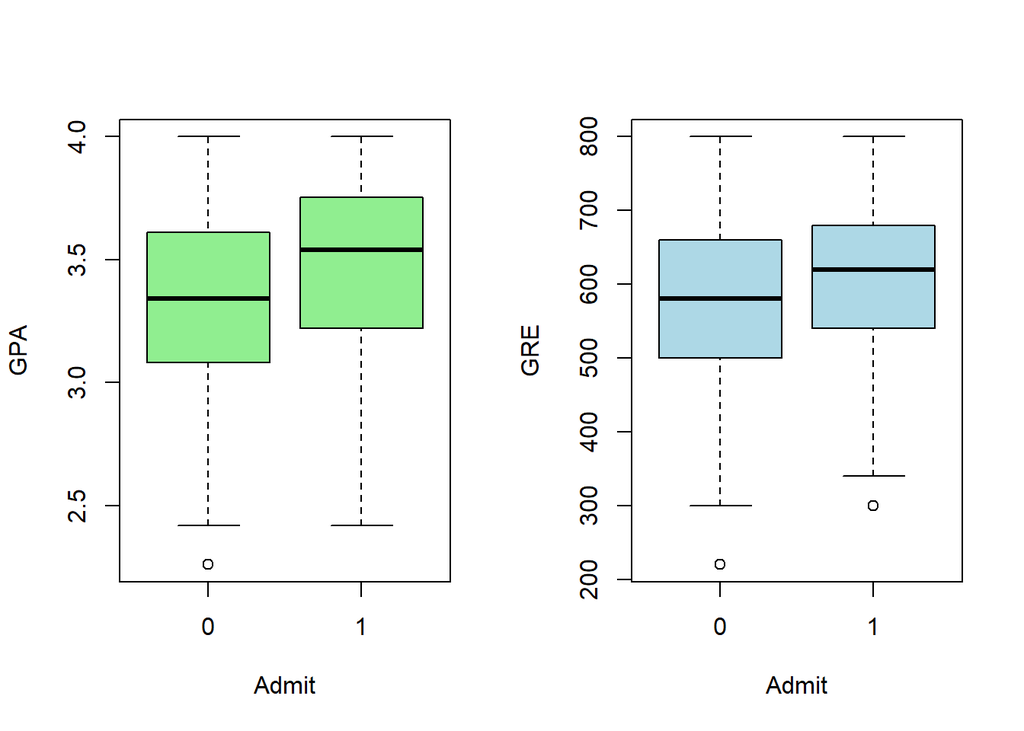

```r
# first, some exploratory visualization
par(mfrow = c(1, 2))
plot(as.factor(d$admit), d$gpa, xlab = "Admit", ylab = "GPA", col = "lightgreen")
plot(as.factor(d$admit), d$gre, xlab = "Admit", ylab = "GRE", col = "lightblue")
```

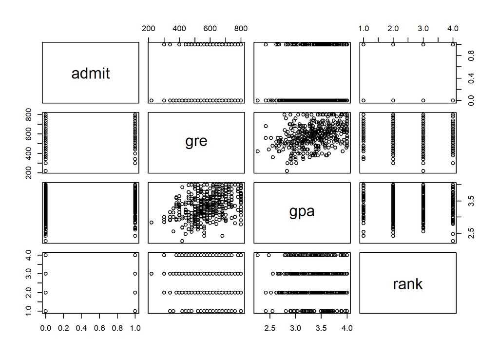

```r
pairs(d)
```

```r
table(d$admit, d$rank)
```

```
##
##      1  2  3  4
##   0 28 97 93 55
##   1 33 54 28 12
```

To use logistic regression to look at how the odds of admission are influenced by GRE scores, we can call the glm() function with a model where admit is our response variable and gre is our predictor variable.

```r
# glm of admit~gre
glm <- glm(data = d, admit ~ gre, family = "binomial")
summary(glm)
```

```
##
## Call:
## glm(formula = admit ~ gre, family = "binomial", data = d)
##
## Deviance Residuals:
##     Min       1Q   Median       3Q      Max
## -1.1623  -0.9052  -0.7547   1.3486   1.9879
##
## Coefficients:
##              Estimate Std. Error z value Pr(>|z|)
## (Intercept) -2.901344   0.606038  -4.787 1.69e-06 ***
## gre          0.003582   0.000986   3.633  0.00028 ***
## ---
## Signif. codes:  0 '***' 0.001 '**' 0.01 '*' 0.05 '.' 0.1 ' ' 1
##
## (Dispersion parameter for binomial family taken to be 1)
##
##     Null deviance: 499.98  on 399  degrees of freedom
## Residual deviance: 486.06  on 398  degrees of freedom
## AIC: 490.06
##
## Number of Fisher Scoring iterations: 4
```

Here is the equation representing the results of our model: logit(πi) = -2.901344 + 0.003582 * gre

#### Interpretation and Hypothesis Testing in Logistic Regression

When we get a β1 estimate from a logistic regression, it represents the change in the log(odds ratio) of the outcome for an increase in one unit of X.

Looking at the coefficient for gre, we see it is positive and, while low, is significantly different from 0. Thus, increasing GRE score results in an increase in the log(odds ratio) of admission (i.e., students with higher scores are more likely to be admitted). Here, for every one unit change in gre, the log odds of admission (versus non-admission) increases by 0.003582.

Using the predict() function, we can plot our data and fit the change in the admitted/not admitted ratio across the range of GRE scores.

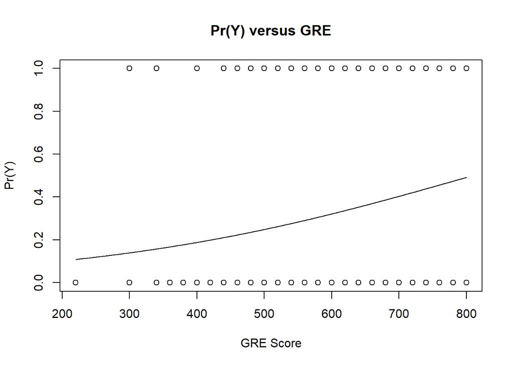

```r
x <- seq(from = min(d$gre), to = max(d$gre), length.out = 1000)
logOR <- predict(glm, newdata = data.frame(gre = x))  # this function will predict the log(odds ratio)... but if we add the argument type='response', the predict() function will return the expected response on the scale of the Y variable, i.e., Pr(Y)=1, rather than the odds ratio!
y <- predict(glm, newdata = data.frame(gre = x), type = "response")
plot(d$admit ~ d$gre, pch = 21, type = "p", xlab = "GRE Score", ylab = "Pr(Y)",
    main = "Pr(Y) versus GRE")
lines(y ~ x, type = "l")
```

By exponentiating β1, we can get the actual odds ratio change (as opposed to the log(odds ratio) change) associated with a 1 unit change in GRE scores.

```r
ORchange <- exp(glm$coefficients[2])
ORchange  # a 1 unit increase in gre results in a 0.36% increase in likelihood of admission
```

```
##      gre
## 1.003589
```

As in simple linear regression, the key H0 of relevance when fitting a simple logistic regression model is that our regression coefficient, βs, is zero, i.e. that there is no relationship between the binary response variable and the predictor variable.

There are two common ways to test this H0. The first is to calculate the Wald statistic for the predictor variable and compare this to the standard normal or z distribution. This is like a ML-based version of a t test. The Wald statistic is, like the t statistic, our β parameter estimate divided by the standard error of that estimate: β1/(SE of β1). This is most appropriate when sample sizes are large. The “z value” in the summary table for the model shows us this statistic.

If we wanted to calculate the Wald statistic by hand, we can do so easily. Below, I use the convenient tidy() function from the {broom} package to pull out a table of results from our GLM very easily.

```r
library(broom)
glmresults <- tidy(glm)
wald <- glmresults$estimate[2]/glmresults$std.error[2]
p <- 2 * (1 - pnorm(wald))  # calculation of 2 tailed p value associated with the Wald statistic
p
```

```
## [1] 0.0002800845
```

We can get the confidence intervals around our estimates using confint() with the model results as an argument. There are two common approaches used to derive these confidence intervals, once based on ML and one based on the standard error associated with the parameter estimates.

```r
CI <- confint(glm, level = 0.95)  # this function returns a CI based on log-likelihood, an iterative ML process
CI
```

```
##                    2.5 %       97.5 %
## (Intercept) -4.119988259 -1.739756286
## gre          0.001679963  0.005552748
```

```r
CI <- confint.default(glm, level = 0.95)  # this function returns CIs based on standard errors, the way we have calculated them by hand previously... note the slight difference
CI
```

```
##                    2.5 %       97.5 %
## (Intercept) -4.089156159 -1.713532380
## gre          0.001649677  0.005514746
```

```r
CI <- glmresults$estimate[2] + c(-1, 1) * qnorm(0.975) * glmresults$std.error[2]  # and this is how we have calculated CIs by hand previously
CI
```

```
## [1] 0.001649677 0.005514746
```

### Challenge 1

Repeat the logistic regression above, but using gpa rather than gre as the predictor variable.

Is gpa a significant predictor of the odds of admission?

What is the estimate of β1 and the 95% CI around that estimate?

How much does an increase of 1 unit in gpa increase the actual odds ratio (as opposed to the log(odds ratio) for admission?

What is the 95% CI around this odds ratio?

(HINT: for both of the latter questions, you will need to apply the exp() function and convert the log(odds ratio) to an odds ratio.)

Graph the probability of admission, Pr(admit), or πi, for students with GPAs between 2.0 and 4.0 GPAs? HINT: Use the predict() function with type=“response” to yield πi directly.

```r
glm <- glm(data = d, admit ~ gpa, family = "binomial")
summary(glm)
```

```
##
## Call:
## glm(formula = admit ~ gpa, family = "binomial", data = d)
##
## Deviance Residuals:
##     Min       1Q   Median       3Q      Max
## -1.1131  -0.8874  -0.7566   1.3305   1.9824
##
## Coefficients:
##             Estimate Std. Error z value Pr(>|z|)
## (Intercept)  -4.3576     1.0353  -4.209 2.57e-05 ***
## gpa           1.0511     0.2989   3.517 0.000437 ***
## ---
## Signif. codes:  0 '***' 0.001 '**' 0.01 '*' 0.05 '.' 0.1 ' ' 1
##
## (Dispersion parameter for binomial family taken to be 1)
##
##     Null deviance: 499.98  on 399  degrees of freedom
## Residual deviance: 486.97  on 398  degrees of freedom
## AIC: 490.97
##
## Number of Fisher Scoring iterations: 4
```

```r
coeffs <- glm$coefficients
coeffs
```

```
## (Intercept)         gpa
##   -4.357587    1.051109
```

```r
CI <- confint(glm, level = 0.95)
CI
```

```
##                  2.5 %    97.5 %
## (Intercept) -6.4334239 -2.367430
## gpa          0.4742282  1.647959
```

```r
ORchange <- exp(coeffs[2])
ORchange
```

```
##      gpa
## 2.860821
```

```r
ORchangeCI <- exp(CI[2, ])
ORchangeCI
```

```
##    2.5 %   97.5 %
## 1.606774 5.196365
```

Now for some visualization…

```r
library(ggplot2)
x <- data.frame(gpa = seq(from = 2, to = 4, length.out = 100))
prediction <- cbind(gpa = x, response = predict(glm, newdata = x, type = "response"))
# IMPORTANT: Using type='response' returns predictions on the scale of our
# Y variable, in this case Pr(admit); using the default for type would
# return a prediction on the logit scale, i.e., the log(odds ratio), or
# log(Pr(admit)/(1-Pr(admit)))
head(prediction)
```

```
##        gpa   response
## 1 2.000000 0.09488728
## 2 2.020202 0.09672673
## 3 2.040404 0.09859796
## 4 2.060606 0.10050136
## 5 2.080808 0.10243733
## 6 2.101010 0.10440626
```

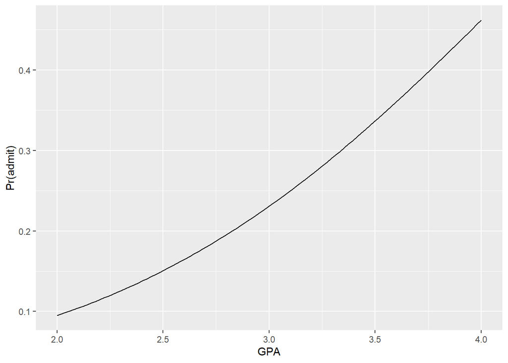

```r
p <- ggplot(prediction, aes(x = gpa, y = response)) + geom_line() + xlab("GPA") +
    ylab("Pr(admit)")
p
```

The predict() function can also be used to get confidence intervals around our estimate of the log(odds of admission) (if “type” is unspecified or set to “link”), or of the probability of admission (if “type” is set to “response”), by using the argument se.fit=TRUE.

```r
prediction <- cbind(gpa = x, predict(glm, newdata = x, type = "response", se = TRUE))
prediction$LL <- prediction$fit - 1.96 * prediction$se.fit
prediction$UL <- prediction$fit + 1.96 * prediction$se.fit
head(prediction)
```

```
##        gpa        fit     se.fit residual.scale         LL        UL
## 1 2.000000 0.09488728 0.03825202              1 0.01991332 0.1698612
## 2 2.020202 0.09672673 0.03840310              1 0.02145665 0.1719968
## 3 2.040404 0.09859796 0.03854537              1 0.02304904 0.1741469
## 4 2.060606 0.10050136 0.03867851              1 0.02469148 0.1763112
## 5 2.080808 0.10243733 0.03880223              1 0.02638497 0.1784897
## 6 2.101010 0.10440626 0.03891621              1 0.02813049 0.1806820
```

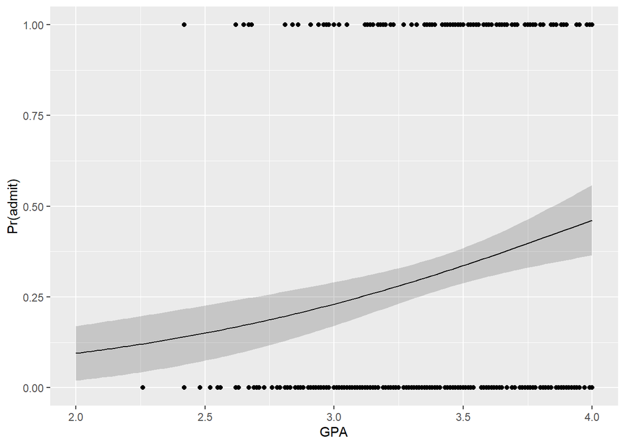

```r
p <- ggplot(prediction, aes(x = gpa, y = fit))
p <- p + geom_ribbon(aes(ymin = LL, ymax = UL), alpha = 0.2) + geom_line() +
    xlab("GPA") + ylab("Pr(admit)")
p <- p + geom_point(data = d, aes(x = gpa, y = admit))
p
```

#### Likelihood Ratio Tests

To evaluate the significance of an **overall model** in a logistic regression, we can compare the fit of a more complex model to that of a nested, reduced model, just as when we discussed model selection approaches for simple linear regression and used partial F tests.

For example, to test the null hypothesis of β1 = 0 for a simple logistic regression model with a single predictor, we would compare the log-likelihood of the full model to that of the reduced, intercept only model. This is called a **likelihood ratio test**. Likelihood ratio tests are similar to partial F-tests in that they compare the full model with a nested, reduced model where the explanatory variables of interest are omitted. Now, however, instead of using a test statistic based on a ratio of variances explained by the two models and interpreting that by comparison to an F distribution, we create a test statistic that is a ratio of the log-likelihoods of the two models. The p values of the tests are calculated using the χ2 distribution with 1 df, but the underlying idea is conceptually the same.

A likelihood ratio test comparing the full and reduced models can be performed using the anova() function with the additional argument test=“Chisq”.

```r
glm1 <- glm(data = d, admit ~ 1, family = "binomial")
glm2 <- glm(data = d, admit ~ gpa, family = "binomial")
anova(glm1, glm2, test = "Chisq")
```

```
## Analysis of Deviance Table
##
## Model 1: admit ~ 1
## Model 2: admit ~ gpa
##   Resid. Df Resid. Dev Df Deviance Pr(>Chi)
## 1       399     499.98
## 2       398     486.97  1   13.009  0.00031 ***
## ---
## Signif. codes:  0 '***' 0.001 '**' 0.01 '*' 0.05 '.' 0.1 ' ' 1
```

Note that the df for the χ2 test is the # of parameters in the proposed model minus **# parameters in the nested model (here, 2-1 = 1)**

With this low p value, we would reject the null hypothesis that removing the variable of interest (gpa) from our model does not result in a loss of fit.

Alternatively, we can use the function lrtest() from the {lmtest} package.

```r
library(lmtest)
lrtest(glm1, glm2)
```

```
## Likelihood ratio test
##
## Model 1: admit ~ 1
## Model 2: admit ~ gpa
##   #Df  LogLik Df  Chisq Pr(>Chisq)
## 1   1 -249.99
## 2   2 -243.48  1 13.009    0.00031 ***
## ---
## Signif. codes:  0 '***' 0.001 '**' 0.01 '*' 0.05 '.' 0.1 ' ' 1
```

We can also perform a likelihood ratio test by hand by taking the difference between the deviances of the two models. The deviance for a generalized linear model is analogous to the the residual sum of squares for a general linear model (low deviance, low RSS = better model). It is calculated as a kind of “distance” of given model from a fully “saturated” model, i.e., a model where each data point has its own parameters. The likelihood of the saturated model = 1 so its log-likelihood is log(1) = 0.

Deviance = 2 × (log-likelihood of the saturated model - log-likelihood of the proposed model)

Deviance = 2 × (0 - log-likelihood of the proposed model)

Deviance = -2 × (log-likelihood of the proposed model)

We can get the deviance associated with a given model object by accessing its $deviance slot or by using the deviance() function with the model object as an argument.

```r
Dglm1 <- glm1$deviance  # intercept only model
Dglm1
```

```
## [1] 499.9765
```

```r
#or
Dglm1 <- deviance(glm1)
Dglm1
```

```
## [1] 499.9765
```

```r
Dglm2 <- glm2$deviance  # model with intercept and one predictor
Dglm2
```

```
## [1] 486.9676
```

```r
#or
Dglm2 <- deviance(glm2)
Dglm2
```

```
## [1] 486.9676
```

```r
chisq <- Dglm1 - Dglm2  # this is a measure of how much the fit improves by adding in the predictor
chisq
```

```
## [1] 13.0089
```

```r
p <- 1 - pchisq(chisq, df = 1)  # df = difference in number of parameters in the full verus reduced model
p
```

```
## [1] 0.0003100148
```

The $null.deviance slot of a model object returns, for any model, the deviance associated with an intercept only null model.

```r
x2 <- glm1$null.deviance - glm1$deviance
x2  # why is this 0? because glm1 *is* the intercept only model!
```

```
## [1] -1.136868e-13
```

```r
p <- 1 - pchisq(x2, df = 1)
p
```

```
## [1] 1
```

```r
x2 <- glm2$null.deviance - glm2$deviance
x2
```

```
## [1] 13.0089
```

```r
p <- 1 - pchisq(x2, df = 1)  # df = difference in number of parameters in the full verus reduced model
p
```

```
## [1] 0.0003100148
```

Here’s some additional useful information about intepreting the results of summary() from running a logistic regression based on this post from StackExchange and this post from The Analysis Factor:

Let n = the number of observations in the data set and k = the number of predictor terms in a proposed model.

- The Saturated Model is a model that assumes each data point has its own parameter, which means we have n parameters to describe the data
- The Null Model is a model that assumes the exact “opposite”, i.e., one parameter describes all of the data points, which means only one parameter, the intercept, is estimated from the data
- The Proposed Model is the model we are fitting by GLM, which has k predictor terms (1 for the intercept + 1 for each predictor variable/interaction term)
- Null Deviance = deviance of null model, calculated as 2(log-likelihood of the saturated model - log-likelihood of a null model), where df = n - 1
- Residual Deviance = 2(log-likelihood of the saturated model - log-likelihood of the proposed model), where df = n - k

If the null deviance is really small, it means that the Null Model explains the data pretty well. Likewise, if the residual deviance is really small, then the Residual Deviance explains the data pretty well.

If you want to compare a Proposed Model against a Null, intercept only model, then you can look at (Null Deviance - Residual Deviance) for that model, which yields a difference that can be examined against Chi Square distribution with k degrees of freedom.

If you want to compare one Proposed model against a nested (reduced) model, then you can look at (Residual Deviance for the reduced model - Residual Deviance for the Proposed model), which again yields a difference that can be examined against Chi Square distribution with df = k proposed model - k nested model.

This deviance-based, Chi Square like statistic is also referred to as a G Square or G statistic. If the p value associated with this statistic is less than the alpha level, it means that the the fuller model is associated with significantly reduced deviance relative to the nested (reduced) model and thus has a better fit. We would thus reject the null hypothesis that the fuller model is not better than the reduced one.

## Multiple Logistic Regression

Logistic regression can be easily extended to situations with multiple predictor variables, including both continuous and categorical variables, as in our discussion of multiple regression under the general linear model.

### Challenge 2

Using the same “graddata.csv” dataset, run a multiple logistic regression analysis using gpa, gre, and rank to look at student admissions to graduate school. Do not, at first, include interaction terms.

- What variables are significant predictors of the log(odds ratio) of admission?
- What is the value of the log(odds ratio) coefficient and the 95% CIs around that value for the two continuous variable (gpa and gre), when taking the effects of the other and of rank into account? What do these translate into on the actual odds ratio scale?
- Is the model including all three predictors better than models that include just two predictors?
- Compare a model that includes the three predictors with no interactions versus one that includes the three predictors and all possible interactions.

```r
d$rank <- as.factor(d$rank)  # make sure rank is a categorical variable
glmGGR <- glm(data = d, formula = admit ~ gpa + gre + rank, family = binomial)  # 3 predictor model
summary(glmGGR)
```

```
##
## Call:
## glm(formula = admit ~ gpa + gre + rank, family = binomial, data = d)
##
## Deviance Residuals:
##     Min       1Q   Median       3Q      Max
## -1.6268  -0.8662  -0.6388   1.1490   2.0790
##
## Coefficients:
##              Estimate Std. Error z value Pr(>|z|)
## (Intercept) -3.989979   1.139951  -3.500 0.000465 ***
## gpa          0.804038   0.331819   2.423 0.015388 *
## gre          0.002264   0.001094   2.070 0.038465 *
## rank2       -0.675443   0.316490  -2.134 0.032829 *
## rank3       -1.340204   0.345306  -3.881 0.000104 ***
## rank4       -1.551464   0.417832  -3.713 0.000205 ***
## ---
## Signif. codes:  0 '***' 0.001 '**' 0.01 '*' 0.05 '.' 0.1 ' ' 1
##
## (Dispersion parameter for binomial family taken to be 1)
##
##     Null deviance: 499.98  on 399  degrees of freedom
## Residual deviance: 458.52  on 394  degrees of freedom
## AIC: 470.52
##
## Number of Fisher Scoring iterations: 4
```

```r
coeff <- glmGGR$coefficients  # extract coefficients... all significantly different from 0
coeffCI <- cbind(coeff, confint(glmGGR))  # and 95% CIs around them... none include 0
coeffCI
```

```
##                    coeff         2.5 %       97.5 %
## (Intercept) -3.989979073 -6.2716202334 -1.792547080
## gpa          0.804037549  0.1602959439  1.464142727
## gre          0.002264426  0.0001375921  0.004435874
## rank2       -0.675442928 -1.3008888002 -0.056745722
## rank3       -1.340203916 -2.0276713127 -0.670372346
## rank4       -1.551463677 -2.4000265384 -0.753542605
```

```r
ORcoeff <- exp(coeff)
ORcoeff
```

```
## (Intercept)         gpa         gre       rank2       rank3       rank4
##   0.0185001   2.2345448   1.0022670   0.5089310   0.2617923   0.2119375
```

```r
ORcoeffCI <- exp(coeffCI)
ORcoeffCI
```

```
##                 coeff       2.5 %    97.5 %
## (Intercept) 0.0185001 0.001889165 0.1665354
## gpa         2.2345448 1.173858216 4.3238349
## gre         1.0022670 1.000137602 1.0044457
## rank2       0.5089310 0.272289674 0.9448343
## rank3       0.2617923 0.131641717 0.5115181
## rank4       0.2119375 0.090715546 0.4706961
```

```r
# Compare 2 verus 3 factor models
glmGG <- glm(data = d, formula = admit ~ gpa + gre, family = binomial)
glmGR <- glm(data = d, formula = admit ~ gpa + rank, family = binomial)
glmRG <- glm(data = d, formula = admit ~ gre + rank, family = binomial)
anova(glmGG, glmGGR, test = "Chisq")
```

```
## Analysis of Deviance Table
##
## Model 1: admit ~ gpa + gre
## Model 2: admit ~ gpa + gre + rank
##   Resid. Df Resid. Dev Df Deviance  Pr(>Chi)
## 1       397     480.34
## 2       394     458.52  3   21.826 7.088e-05 ***
## ---
## Signif. codes:  0 '***' 0.001 '**' 0.01 '*' 0.05 '.' 0.1 ' ' 1
```

```r
anova(glmGR, glmGGR, test = "Chisq")
```

```
## Analysis of Deviance Table
##
## Model 1: admit ~ gpa + rank
## Model 2: admit ~ gpa + gre + rank
##   Resid. Df Resid. Dev Df Deviance Pr(>Chi)
## 1       395     462.88
## 2       394     458.52  1   4.3578  0.03684 *
## ---
## Signif. codes:  0 '***' 0.001 '**' 0.01 '*' 0.05 '.' 0.1 ' ' 1
```

```r
anova(glmRG, glmGGR, test = "Chisq")
```

```
## Analysis of Deviance Table
##
## Model 1: admit ~ gre + rank
## Model 2: admit ~ gpa + gre + rank
##   Resid. Df Resid. Dev Df Deviance Pr(>Chi)
## 1       395     464.53
## 2       394     458.52  1   6.0143  0.01419 *
## ---
## Signif. codes:  0 '***' 0.001 '**' 0.01 '*' 0.05 '.' 0.1 ' ' 1
```

```r
# Compare model with and model without interactions
glmNO <- glm(data = d, admit ~ rank + gpa + gre, family = "binomial")
glmALL <- glm(data = d, admit ~ rank * gpa * gre, family = "binomial")
anova(glmNO, glmALL, test = "Chisq")  # adding interaction terms to model doesn't significantly decrease deviance
```

```
## Analysis of Deviance Table
##
## Model 1: admit ~ rank + gpa + gre
## Model 2: admit ~ rank * gpa * gre
##   Resid. Df Resid. Dev Df Deviance Pr(>Chi)
## 1       394     458.52
## 2       384     450.39 10   8.1317    0.616
```

## Log-Linear or Poisson Regression

Sometimes, we want to model a response variable that is in the form of count data (e.g., species richness on an island in terms of distance from the mainland, number of plants of a particular species found in a sampling plot in relation to altitude). Many discrete response variables have counts as possible outcomes. Binomial counts are the number of successes x in a fixed number of trials, n. Poisson counts are the number occurrences of some event in a certain interval of time (or space). While binomial counts only take values between 0 and n, Poisson counts have no upper bound. We are going to focus on Poisson counts here.

As we have discussed before, for Poisson distributed variables, the mean and the variance are equal and represented by a single parameter (λ), and therefore linear models based on normal distributions may not be appropriate. We have seen that sometimes we can simply transform a response variable with some kind of power transformation to make it appear more normally distributed, but an alternative is to use a GLM with a Poisson error term and use a log transformation as the link function, resulting in in a **log-linear** model. Thus, when we do Poisson regression, our regression model tries to predict the natural log of the expected value of Y, i.e., λi.

The link function is thus:

g = log(ui)

The inverse link function is, then:

lambdai = e^lambdai

Our regression formulation is the same as in logistic regression, above, except we use family=“Poisson”, e.g, glm(y ~ x, family = “poisson”)